# A Gentle Introduction to `jamovi`

Interface, Data, and Variables

Aaron R. Baggett, Ph.D.

true  
abaggett@umhb.edu

2026-08-13

## What This Is

These are the notes from our first in-class jamovi walkthrough. If you were there, this is a step-by-step record of what we did, so you can redo it on your own time. If you missed class, welcome — everything you need to follow along is right here.

Nothing here is graded. The goal today was simple: get comfortable clicking around a real statistics program before we ask you to do anything complicated with it.

## Haven’t installed jamovi yet?

See the separate **“Getting Started with jamovi”** guide for Windows, macOS, and iPad installation steps before continuing.

## The Dataset We Used

We worked with a real, publicly available subset of the **General Social Survey (GSS)** — a survey of U.S. adults that NORC at the University of Chicago has been running since 1972. Every row is a real person’s real answers, not made-up numbers.

| Variable | What it is | Type |
| --- | --- | --- |
| `age` | respondent’s age (years) | continuous |
| `hours_worked` | hours worked in the week before the survey | discrete |
| `household_size` | number of people in the household | discrete |
| `sex` | male / female | categorical |
| `college_degree` | has a college degree or not | categorical |

You’ll see this exact dataset again later in the semester — once in Module 2 when we dig deeper into describing data, and again in Module 5 when we learn to formally test group differences like the one we eyeballed today.

- Download [`gss_tv_hours_demo.omv`](https://mycourses.umhb.edu/courses/45756/modules/items/1455766) from Canvas

## Step 1: Get Oriented

1. **Data view** — a spreadsheet, just like Excel or Google Sheets.
2. **Variables view** — a second tab that describes each column (what *kind* of information it holds).
3. **Analyses ribbon** — the row of buttons across the top (Exploration, T-Tests, ANOVA, Regression, Frequencies, and more). We’ll only use *Exploration* today — the rest will make sense as the semester goes on.
4. **Results panel** — appears on the right side once you actually run something. It’s empty right now.

[figure not shown]

jamovi runs on top of R behind the scenes, but you never have to see or write any code to use it. Think of it as training wheels for the kind of thinking we’ll build toward in R later this semester.

## Step 2: Import the Data

**On jamovi Cloud (iPad/browser):**

`File` → `Import` → choose the file from your device or connected cloud storage

[figure not shown]

## Step 3: Check Your Variable Types

jamovi guesses what *kind* of variable each column is when you import it — sometimes it guesses wrong, so it’s worth double-checking. Switch to the **Variables** tab (or double-click a column header):

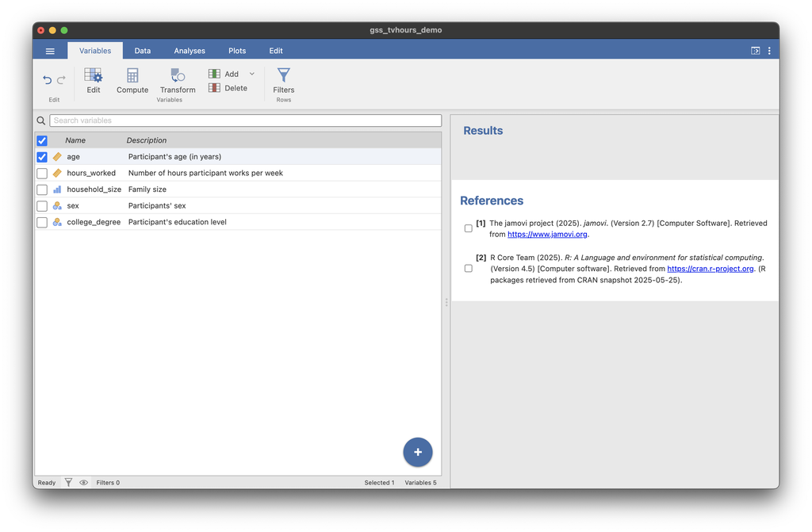

This connects directly to something we’ll spend a whole class period on soon: **data types**. For now, just notice that jamovi cares about the difference between a number that measures something (`age`) and a number, or word, that just labels a group (`sex`).

## Step 4: Describe the Data

Here’s where we started asking jamovi real questions.

`Analyses` → `Exploration` → `Descriptives`, then move `age`, `hours_worked`, and `household_size` into the **Variables** box.

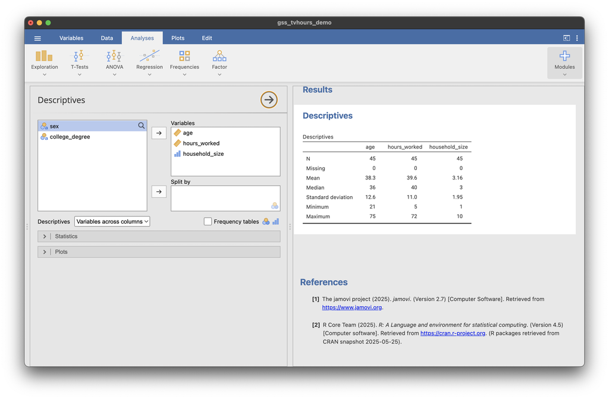

You should see a table like this:

| Variable | N | Mean | Median | SD | Min | Max |
| --- | --- | --- | --- | --- | --- | --- |
| age | 45 | 38.29 | 36 | 12.60 | 21 | 75 |
| hours_worked | 45 | 39.56 | 40 | 10.96 | 5 | 72 |
| household_size | 45 | 3.16 | 3 | 1.95 | 1 | 10 |

**Notice anything interesting?** Someone in our sample lives in a 10-person household — well above the average of about 3. Is that a mistake in the data, or just real human variation? Questions like that are exactly what the rest of this course is about.

## Step 5: Split by Group

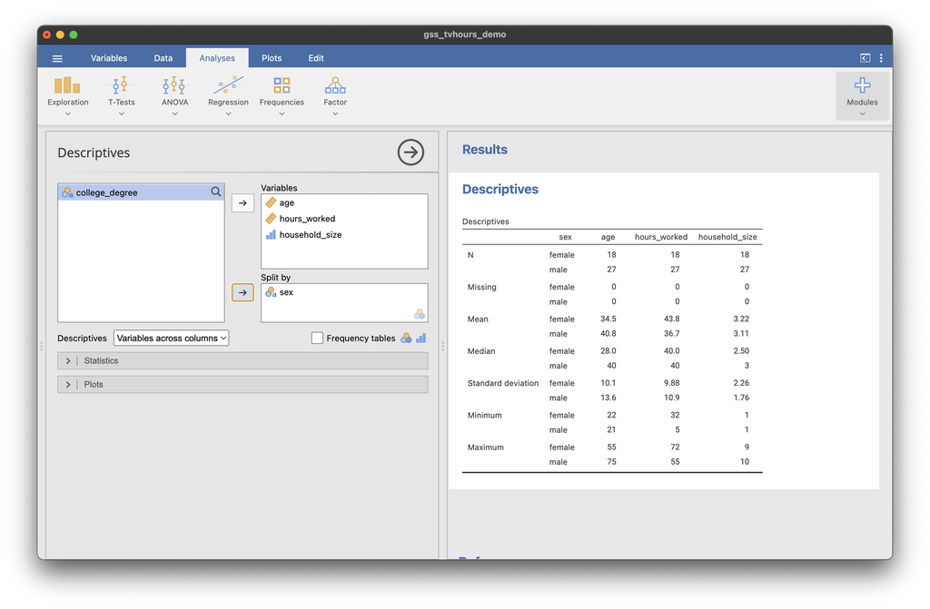

| Variable | Group | N | Mean | SD |
| --- | --- | --- | --- | --- |
| age | male | 27 | 40.8 | 13.6 |
| age | female | 18 | 34.5 | 10.1 |
| hours_worked | male | 27 | 36.7 | 10.9 |
| hours_worked | female | 18 | 43.8 | 9.9 |
| household_size | male | 27 | 3.1 | 1.8 |
| household_size | female | 18 | 3.2 | 2.3 |

We’re only **looking** right now — we haven’t tested whether these differences are statistically meaningful or just due to chance in a small sample. That’s exactly what **Module 5: Basics of Hypothesis Testing** will teach you to do, later this semester, with this same dataset.

## Step 6: Make a Picture

Still in Descriptives, we opened the **Plots** section and checked **Histogram** for `age`.

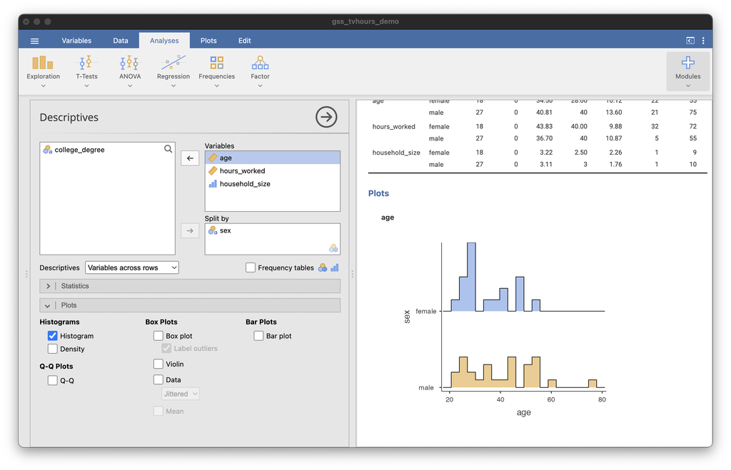

**Try it yourself:** switch the histogram to `household_size` instead. What shape do you notice? Does anything stand out as unusual compared to the rest of the sample?

## Reflect

A few questions to check your own understanding — no need to write these down or turn them in, just think them through:

1. Which of our three quantitative variables had the largest standard deviation? What does a large SD tell you about a variable, in plain language?
2. Looking at the split-by-`sex` table, does average `hours_worked` *look* different between men and women in our sample? What would you need to know before concluding it’s a “real” difference and not just chance?
3. If you switched the histogram to `household_size`, how would you describe its shape to a friend who’s never seen it?

## Where We’re Headed

- **Week 2:** Data types and sampling — today’s Variables-tab detour becomes a full lecture
- **Module 2:** We’ll come back to this same dataset to describe and visualize it in much more depth
- **Module 5:** We’ll formally test that male/female `hours_worked` gap we noticed today

## Data Source

General Social Survey (GSS), NORC at the University of Chicago — a nationally representative survey of U.S. adults conducted since 1972. This 45-respondent classroom sample (drawn from GSS waves 1973–2018) comes from the `gss` teaching dataset distributed in the R `infer` package (tidymodels). Every row is a real survey respondent’s real answers.